# Week 5: Dimensionality reduction techniques

This week I’ll dive into dimensionality reduction techniques.

## 1) Graphical overview and summaries of the data

```r
library(MASS); library(dplyr); library(corrplot); library(ggplot2); library(GGally); library(tidyr)

human <- read.csv2(file = "data/human.csv", sep = ",", dec = ".")

str(human)
```

```
## 'data.frame':    155 obs. of  8 variables:
##  $ Edu2.FM  : num  1.007 0.997 0.983 0.989 0.969 ...
##  $ Labo.FM  : num  0.891 0.819 0.825 0.884 0.829 ...
##  $ Edu.Exp  : num  17.5 20.2 15.8 18.7 17.9 16.5 18.6 16.5 15.9 19.2 ...
##  $ Life.Exp : num  81.6 82.4 83 80.2 81.6 80.9 80.9 79.1 82 81.8 ...
##  $ GNI      : int  166 135 156 139 140 137 127 154 134 117 ...
##  $ Mat.Mor  : int  4 6 6 5 6 7 9 28 11 8 ...
##  $ Ado.Birth: num  7.8 12.1 1.9 5.1 6.2 3.8 8.2 31 14.5 25.3 ...
##  $ Parli.F  : num  39.6 30.5 28.5 38 36.9 36.9 19.9 19.4 28.2 31.4 ...
```

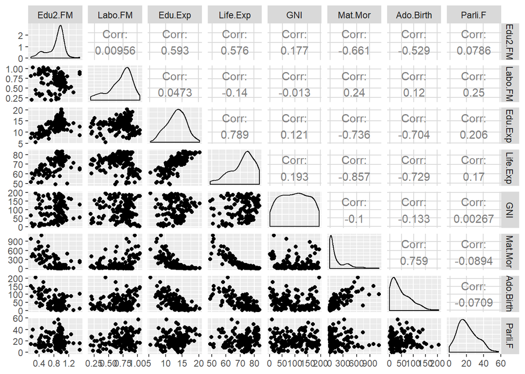

```r
g1 <- ggpairs(human)
g1
```

```r
summary(human)
```

```
##     Edu2.FM          Labo.FM          Edu.Exp         Life.Exp
##  Min.   :0.1717   Min.   :0.1857   Min.   : 5.40   Min.   :49.00
##  1st Qu.:0.7264   1st Qu.:0.5984   1st Qu.:11.25   1st Qu.:66.30
##  Median :0.9375   Median :0.7535   Median :13.50   Median :74.20
##  Mean   :0.8529   Mean   :0.7074   Mean   :13.18   Mean   :71.65
##  3rd Qu.:0.9968   3rd Qu.:0.8535   3rd Qu.:15.20   3rd Qu.:77.25
##  Max.   :1.4967   Max.   :1.0380   Max.   :20.20   Max.   :83.50
##       GNI            Mat.Mor         Ado.Birth         Parli.F
##  Min.   :  2.00   Min.   :   1.0   Min.   :  0.60   Min.   : 0.00
##  1st Qu.: 53.50   1st Qu.:  11.5   1st Qu.: 12.65   1st Qu.:12.40
##  Median : 99.00   Median :  49.0   Median : 33.60   Median :19.30
##  Mean   : 98.73   Mean   : 149.1   Mean   : 47.16   Mean   :20.91
##  3rd Qu.:143.50   3rd Qu.: 190.0   3rd Qu.: 71.95   3rd Qu.:27.95
##  Max.   :194.00   Max.   :1100.0   Max.   :204.80   Max.   :57.50
```

Data has 8 variables and 155 observations, which are countries.

From the pairs plot we see that Life.exp and Edu.exp and Mat.Mor and Ado.Birth have a high positive correlation. Life.exp has a high negative correlation both with Mat.mor & Ado.birth.

From summaries we see that there is a high variation in life.exp and edu.exp between observations.

## 2) Principal component analysis (PCA) not standardised

```r
# perform principal component analysis (with the SVD method)
pca_human <- prcomp(human)

summary(pca_human)
```

```
## Importance of components:
##                             PC1      PC2      PC3      PC4     PC5     PC6
## Standard deviation     214.3202 54.48589 26.38141 11.47911 4.06687 1.60671
## Proportion of Variance   0.9233  0.05967  0.01399  0.00265 0.00033 0.00005
## Cumulative Proportion    0.9233  0.98298  0.99697  0.99961 0.99995 1.00000
##                           PC7    PC8
## Standard deviation     0.1905 0.1587
## Proportion of Variance 0.0000 0.0000
## Cumulative Proportion  1.0000 1.0000
```

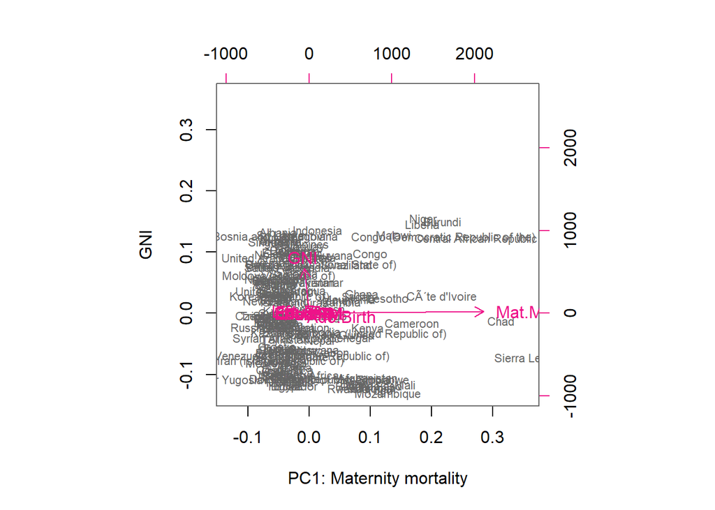

```r
# draw a biplot of the principal component representation and the original variables
biplot(pca_human, choices = 1:2, cex = c(0.7,1), col = c("grey40", "deeppink2"), xlab = "PC1: Maternity mortality", ylab = "GNI")
```

## 3) Same but standardized

```r
human_std <- scale(human)

# perform principal component analysis (with the SVD method)
pca_human_std <- prcomp(human_std)

summary(pca_human_std)
```

```
## Importance of components:
##                          PC1    PC2    PC3     PC4     PC5     PC6     PC7
## Standard deviation     1.966 1.1388 0.9900 0.86598 0.69931 0.54001 0.46701
## Proportion of Variance 0.483 0.1621 0.1225 0.09374 0.06113 0.03645 0.02726
## Cumulative Proportion  0.483 0.6452 0.7677 0.86140 0.92253 0.95898 0.98625
##                            PC8
## Standard deviation     0.33172
## Proportion of Variance 0.01375
## Cumulative Proportion  1.00000
```

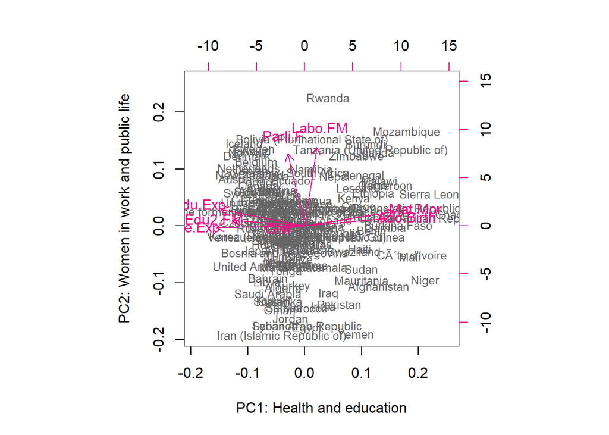

```r
# draw a biplot of the principal component representation and the original variables
biplot(pca_human_std, choices = 1:2, cex = c(0.8,1), col = c("grey40", "deeppink2"), xlab="PC1: Health and education", ylab="PC2: Women in work and public life")
```

Results of the standardized and non-standardized PCA are very different, since on the non standardized version the variabels with very high values get more weight to the analysis.

The non-standarized PC1 has Mat.Mor as a contributor, and PC2 GNI as a contributor. Both of them have really high standard deviations 214.3 and 54.5, which is caused by the missing scaling and high deviation of Mat.Mor and GNI.

Then on the scaled PC1 and PC2 the sd:s are 1.966 and 1.1388, which is a lot better. Therefor scaled Principal components have more contributing variables, when Mat.mor and GNI are not overweighting anymore.

## 4) Personal interpretation on the standardized PC1 ans PC2

Mat.Mor, Ado.Birth, Edu.Exp, Edu2.FM, GNI and Life.Exp are pointing on PC1 axis, so they contribute to Principal component 1. This means that PC1 consist about Health related variables (life expectency, maternity mortality) and education (ratio and expected time).

Parli.F and Labo.FM are pointing towards PC2 axis, which mean they contribute to Principal component 2. This means PC2 consist of womens repsentation in the work and official public life.

## 5) Multiple Correspondence Analysis

```r
library(FactoMineR)

data("tea")

str(tea)
```

```
## 'data.frame':    300 obs. of  36 variables:
##  $ breakfast       : Factor w/ 2 levels "breakfast","Not.breakfast": 1 1 2 2 1 2 1 2 1 1 ...
##  $ tea.time        : Factor w/ 2 levels "Not.tea time",..: 1 1 2 1 1 1 2 2 2 1 ...
##  $ evening         : Factor w/ 2 levels "evening","Not.evening": 2 2 1 2 1 2 2 1 2 1 ...
##  $ lunch           : Factor w/ 2 levels "lunch","Not.lunch": 2 2 2 2 2 2 2 2 2 2 ...
##  $ dinner          : Factor w/ 2 levels "dinner","Not.dinner": 2 2 1 1 2 1 2 2 2 2 ...
##  $ always          : Factor w/ 2 levels "always","Not.always": 2 2 2 2 1 2 2 2 2 2 ...
##  $ home            : Factor w/ 2 levels "home","Not.home": 1 1 1 1 1 1 1 1 1 1 ...
##  $ work            : Factor w/ 2 levels "Not.work","work": 1 1 2 1 1 1 1 1 1 1 ...
##  $ tearoom         : Factor w/ 2 levels "Not.tearoom",..: 1 1 1 1 1 1 1 1 1 2 ...
##  $ friends         : Factor w/ 2 levels "friends","Not.friends": 2 2 1 2 2 2 1 2 2 2 ...
##  $ resto           : Factor w/ 2 levels "Not.resto","resto": 1 1 2 1 1 1 1 1 1 1 ...
##  $ pub             : Factor w/ 2 levels "Not.pub","pub": 1 1 1 1 1 1 1 1 1 1 ...
##  $ Tea             : Factor w/ 3 levels "black","Earl Grey",..: 1 1 2 2 2 2 2 1 2 1 ...
##  $ How             : Factor w/ 4 levels "alone","lemon",..: 1 3 1 1 1 1 1 3 3 1 ...
```

[output cut: 22 more lines]

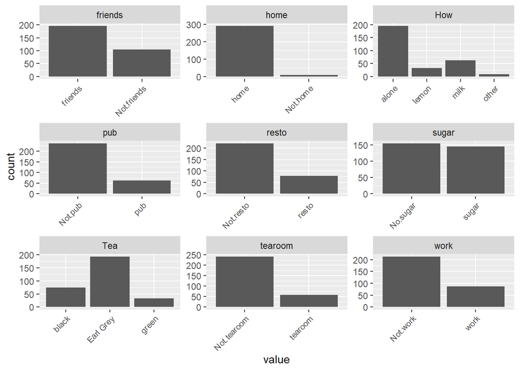

```r
# visualize variables home, work, tearoom, friends, resto, pub, Tea, How, sugar
gather(tea[,7:15]) %>% ggplot(aes(value)) + facet_wrap("key", scales = "free") + geom_bar() + theme(axis.text.x = element_text(angle = 45, hjust = 1, size = 8))
```

Tea is a dataset of different factor variables (36) connected to tea drinking on 300 observations.

```r
# MCA with variables: home, work, tearoom, friends, resto, pub, Tea, How, sugar
mca <- MCA(tea[,7:15], graph = FALSE)

# summary of the model
summary(mca)
```

```
##
## Call:
## MCA(X = tea[, 7:15], graph = FALSE)
##
##
## Eigenvalues
##                        Dim.1   Dim.2   Dim.3   Dim.4   Dim.5   Dim.6
## Variance               0.206   0.161   0.126   0.121   0.114   0.107
## % of var.             15.415  12.043   9.433   9.108   8.585   8.031
## Cumulative % of var.  15.415  27.458  36.891  45.999  54.585  62.615
##                        Dim.7   Dim.8   Dim.9  Dim.10  Dim.11  Dim.12
## Variance               0.103   0.093   0.088   0.080   0.069   0.065
## % of var.              7.713   6.971   6.636   5.973   5.208   4.884
## Cumulative % of var.  70.328  77.299  83.935  89.908  95.116 100.000
##
## Individuals (the 10 first)
##                Dim.1    ctr   cos2    Dim.2    ctr   cos2    Dim.3    ctr
## 1           | -0.512  0.424  0.300 |  0.208  0.090  0.049 |  0.180  0.086
## 2           | -0.474  0.364  0.185 |  0.621  0.802  0.318 |  0.581  0.894
## 3           |  0.392  0.249  0.165 | -0.038  0.003  0.002 |  0.002  0.000
## 4           | -0.461  0.345  0.358 | -0.264  0.144  0.117 |  0.086  0.020
## 5           | -0.472  0.361  0.384 |  0.052  0.006  0.005 | -0.111  0.032
## 6           | -0.472  0.361  0.384 |  0.052  0.006  0.005 | -0.111  0.032
## 7           | -0.200  0.065  0.094 | -0.036  0.003  0.003 | -0.276  0.201
## 8           | -0.474  0.364  0.185 |  0.621  0.802  0.318 |  0.581  0.894
## 9           | -0.423  0.291  0.191 |  0.150  0.047  0.024 |  0.487  0.627
## 10          | -0.170  0.047  0.022 |  0.714  1.059  0.394 | -0.151  0.060
##               cos2
## 1            0.037 |
## 2            0.278 |
## 3            0.000 |
## 4            0.012 |
## 5            0.021 |
## 6            0.021 |
## 7            0.177 |
## 8            0.278 |
## 9            0.252 |
## 10           0.018 |
##
## Categories (the 10 first)
```

[output cut: 19 more lines]

```
## Not.friends   2.637 |   0.344   3.620   0.063   4.331 |
## Not.resto    -2.621 |  -0.091   0.533   0.023  -2.617 |
## resto         2.621 |   0.253   1.491   0.023   2.617 |
##
## Categorical variables (eta2)
##               Dim.1 Dim.2 Dim.3
## home        | 0.005 0.130 0.010 |
## work        | 0.189 0.025 0.061 |
## tearoom     | 0.322 0.074 0.029 |
## friends     | 0.278 0.023 0.063 |
## resto       | 0.411 0.023 0.023 |
## pub         | 0.233 0.016 0.133 |
## Tea         | 0.213 0.531 0.128 |
## How         | 0.198 0.299 0.587 |
## sugar       | 0.000 0.324 0.098 |
```

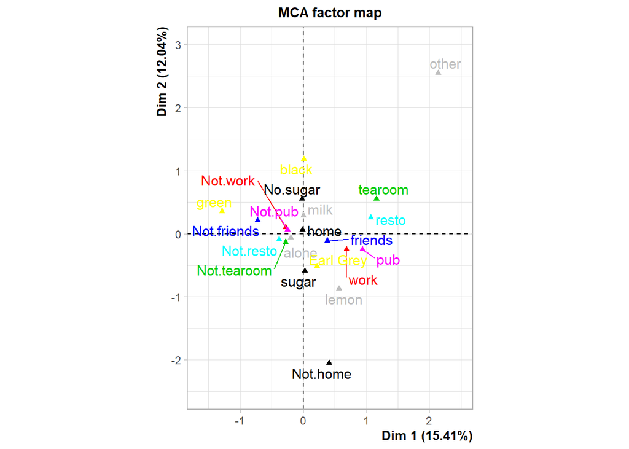

```r
# visualize MCA
plot(mca, invisible=c("ind"), habillage = "quali")
```

MCA biplot shows variable patterns. We see that different not factor values are similar (not.friends, not.restoraunt, not.tearoom, not.pub and alone) which imply to drinking tea alone and not in public places. Not.home is far from other variables. Earl Grey and sugar also seem to go together.